# The Prosper Loan Data Exploration

## Investigation Overview

> This is a finanacial dataset related to the loan, lenders, borrowers, interest rates, monthly payments, incomes, etc. This dataset is from the Propsper Marketplace Inc., a San Francisco California based company specializing in loan at low interest rates to the borrowers. The variables included the borrower's location, financial, credit records, the evaluation measurement made by the Prosper platform, and the investors' information. In the next few sections, I will clean up the data and explore the loan data through applying univariate, bivariate, and multivariate graphs and summaries. Specifically, I explored the dataset to address the concerns listed below.
> 1. What are the characteristics of the borrowers on the Prosper platform.
> 2. What are the factors that play critical roles in determining the borrower rate.
> 3. How the Prosper platform evaluate and manage the risk for the investors.
> 4. The pattern of the investors' preference in choosing the borrowers.

## Dataset Overview

> The dataset contains 113,937 loans with 81 variables. Each loan record contains the loan amount, borrower rate (interest rate), current loan status, borrower's employment status, borrower income, and borrower credit history.

> The data analysis below is based on my personal interests listed above, therefore I pre-selected the data accordingly.

```python
# import all packages and set plots to be embedded inline
import numpy as np
import pandas as pd
import matplotlib.pyplot as plt
import seaborn as sb

%matplotlib inline

# suppress warnings from final output
import warnings
warnings.simplefilter("ignore")
```

```python
# load in the dataset into a pandas dataframe
# load in the dataset into a pandas dataframe
loan = pd.read_csv('prosperLoanData.csv')
```

> Note that the above cells have been set as "Skip"-type slides. That means that when the notebook is rendered as http slides, those cells won't show up.

## Who borrows money on Prosper and the reasons

> The chart clearly shows most borrowers on Prosper live in California, followed by Texas, New York, and Florida. Since the Prosper is located in California, it is not surprising that the people live in California using the Prosper plaform. The other interesting finding from this chart is in general, theere are more borrowers from the coast line states than the inner states.

> The top five states of the borrowers on Prosper are California, Texas, New York, Florida, and Illinois.

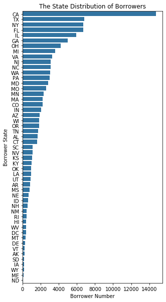

```python
# plotting the EmploymentStatus
color_base = sb.color_palette()[0]
plt.figure(figsize = [5, 10])
sb.countplot(data = loan, y = 'BorrowerState', color = color_base,
             order = loan['BorrowerState'].value_counts().index)

plt.xlabel('Borrower Number')
plt.ylabel('Borrower State')
plt.title('The State Distribution of Borrowers')
```

## Where the large sum of money go?

Since most of the money went to the top five states as shown above, I focused on the top five states and further investigated where the large amount of loan money went.

> - The plot shows five significant peaks of the original amount of the loan: 4k, 10k, 15k, 20k, and 25k.
> - The 4k peak is very peculiar compare to the rest four peaks because the loan amount is much smaller and unlike the rest major peaks, 4k falls out of the 5k arithmeci sequence the rest four peaks follows.
> - So, why so many borrowers borrow 4k on Prosper?

*Before I dive into the dataset, let's explore the another aspect of the borrower's background information.*

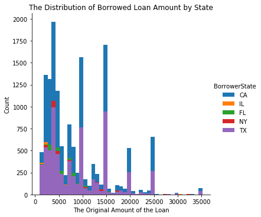

```python
# set the borrower state range
loan_sub = loan.loc[loan['BorrowerState'].isin(['CA', 'TX', 'NY', 'FL', 'IL'])]

# plotting histogram
binsize = 833.7
bins = np.arange(999, loan_sub['LoanOriginalAmount'].max()+binsize, binsize);
group_order = ['CA', 'FL', 'IL', 'NY', 'TX']

# plot the histogram of the BorrowerRate
g = sb.FacetGrid(data = loan_sub, hue = 'BorrowerState',
                 height = 5)
g.map(plt.hist, 'LoanOriginalAmount', bins = bins, histtype = 'bar')
g.add_legend()

# chart labels
plt.xlabel('The Original Amount of the Loan')
plt.ylabel('Count')
plt.title('The Distribution of Borrowed Loan Amount by State')
```

## What the borrowers do for a living

> - Most borrowers on Prosper are Professional, Computer Programmer, Executive, Teacher, Aministrative Assistant, and Analyst. Note: The borrowers who self-identified as 'Other' in the occupation column have been excluded from the this analysis.
> - The top five occupation workers are usually regarded as well educated, creditworthy, and have relatively high income.
> - The large number of executives also borrow money from the Prosper platform is very surprising.

*Next, let's get the details of the borrower's employment status and check their income ranges.*

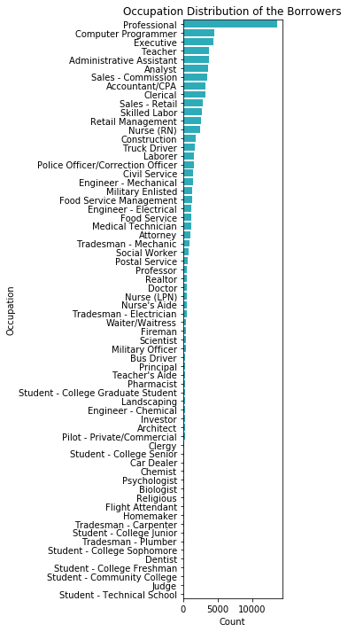

```python
# check the borrowers
# set a big chart
loan1 = loan[loan['Occupation'] != 'Other']
plt.figure(figsize = [2, 12])
color_2 = sb.color_palette()[9]
sb.countplot(data = loan1, y = 'Occupation', color = color_2,
             order = loan1['Occupation'].value_counts().index)

plt.title('Occupation Distribution of the Borrowers');
plt.xlabel('Count');
plt.ylabel('Occupation');
```

## (The borrower's occupation and income ranges)

> - Most borrowers on Prosper self-identified as Professional, Computer Programmer, Executive, Teacher, Aministrative Assistant, and Analyst. Note: The borrowers who self-identified as 'Other' in the occupation column have been excluded from the this analysis.
> - The top five occupation workers are usually regarded as well educated, creditworthy, and have relatively high income.
> - The large number of executives also borrow money from the Prosper platform is very surprising.
> - Most the borrowers are identified as employed (67322 counts), and 26355 have full-time works, followed by 6134 self-employed borrowers.
> - The top three income ranges of the borrowers are USD 25,000-USD 49,999 followed by USD 50,000-USD 74,999 and USD 100,000+.

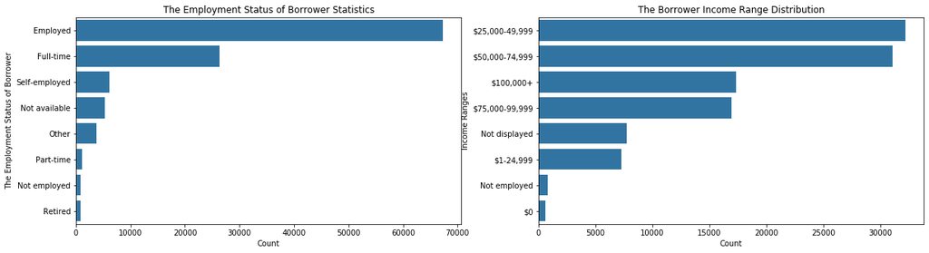

```python
# plot a big chart
plt.figure(figsize = [20, 5])

# left chart, the EmploymentStatus
plt.subplot(1, 2, 1)
sb.countplot(data = loan, y = 'EmploymentStatus', color = color_base,
             order = loan['EmploymentStatus'].value_counts().index)
# axis labels
plt.xlabel('Count')
plt.ylabel('The Employment Status of Borrower')
plt.title('The Employment Status of Borrower Statistics')

# right chart, the Income Range counts
plt.subplot(1, 2, 2)
sb.countplot(data = loan, y = 'IncomeRange', color = color_base,
             order = loan['IncomeRange'].value_counts().index)

plt.xlabel('Count')
plt.ylabel('Income Ranges')
plt.title('The Borrower Income Range Distribution')
```

## What was the loan used for?

> - The top reason for borrowing was debt consolidation, followed by home improvement, business, auto and personal loan sequentially.

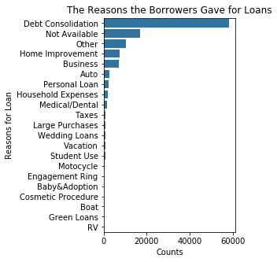

```python
plt.figure(figsize = [3, 5])

# set the borrower state range
sb.countplot(data = loan, y = 'ListingCategory (numeric)', color = color_base,
             order = loan['ListingCategory (numeric)'].value_counts().index)
ytick_locs = [0, 1, 2, 3, 4, 5, 6, 7, 8, 9, 10, 11, 12, 13, 14, 15, 16, 17, 18, 19, 20]
ytick_sbl = ['Debt Consolidation', 'Not Available', 'Other', 'Home Improvement', 'Business', 'Auto', 'Personal Loan',
             'Household Expenses', 'Medical/Dental', 'Taxes', 'Large Purchases', 'Wedding Loans',
             'Vacation', 'Student Use', 'Motocycle', 'Engagement Ring', 'Baby&Adoption',
             'Cosmetic Procedure', 'Boat', 'Green Loans', 'RV']
plt.yticks(ytick_locs, ytick_sbl)

plt.title('The Reasons the Borrowers Gave for Loans')
plt.xlabel('Counts')
plt.ylabel('Reasons for Loan')
```

## Other important features of the borrowers on Prosper

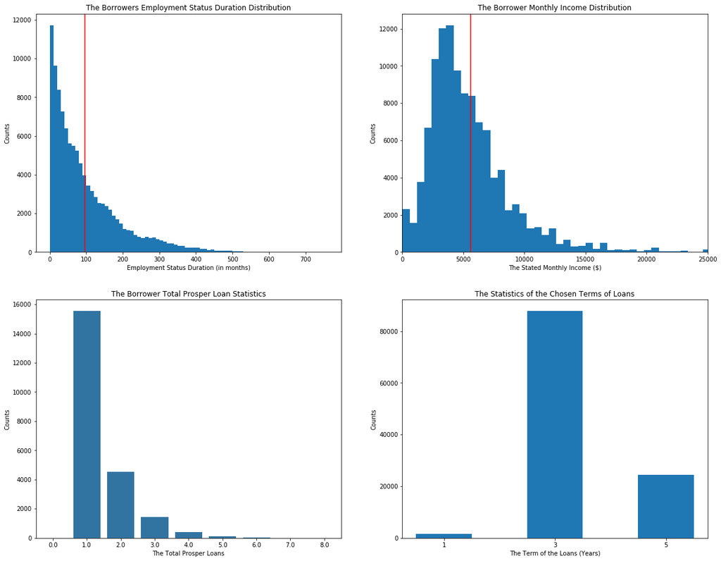

```python
# set a big chart
plt.figure(figsize = [20, 16])
color_base = sb.color_palette()[0]

# the top left one, EmploymentStatusDuration
plt.subplot(2, 2, 1)
binsize = 10
bins = np.arange(0, 755+binsize, binsize);
plt.hist(data = loan, x = 'EmploymentStatusDuration', bins = bins, color = color_base);
plt.xlabel('Employment Status Duration (in months)')
plt.ylabel('Counts')
plt.title('The Borrowers Employment Status Duration Distribution')
plt.axvline(x = 96, color = 'r') # indicate the mean value

# the top right chart, StatedMonthlyIncome
plt.subplot(2, 2, 2)
binsize = 600
bins = np.arange(0, 1750003+binsize, binsize)
plt.hist(data = loan, x = 'StatedMonthlyIncome', bins = bins, color = color_base)
plt.xlim(0, 25000)
plt.xlabel('The Stated Monthly Income ($)')
plt.ylabel('Counts')
plt.title('The Borrower Monthly Income Distribution')
plt.axvline(x = 5.608026e+03, color = 'r') # the location of the red line indicate the mean value

# the bottom left chart, TotalProsperLoans
plt.subplot(2, 2, 3)
sb.countplot(data = loan, x = 'TotalProsperLoans', color = color_base)
plt.title('The Borrower Total Prosper Loan Statistics')
plt.xlabel('The Total Prosper Loans')
plt.ylabel('Counts')

# the bottom right chart, LoanReasons
plt.subplot(2, 2, 4)
# start with a standard-scaled plot
binsize = 12
bins = np.arange(4, 76, 12)

plt.hist(data = loan, x = 'Term', bins = bins)
plt.xticks([10, 34, 58], [1, 3, 5])
plt.xlabel('The Term of the Loans (Years)')
plt.ylabel('Counts')
plt.title('The Statistics of the Chosen Terms of Loans')
plt.show()
```

## Can the borrowers make their payment ontime?

> - Most borrowers make their loan payment ontime.
> - Very few borrowers finally cancelled their loan on Prsoper.

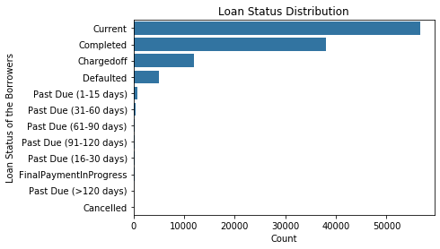

```python
# the bar chart of the listing category variables
sb.countplot(data = loan, y = 'LoanStatus', color = color_base,
             order = loan['LoanStatus'].value_counts().index)

plt.title('Loan Status Distribution');
plt.xlabel('Count');
plt.ylabel('Loan Status of the Borrowers');
#plt.xscale('log')
#plt.xticks([10, 100, 1000, 10000, 50000],
#           ['10', '100', '1k', '10k', '5k']);
```

### So far we have a general idea about the borrowers' background information and loan money they borrowed.

### Next, I want to understand how the Prosper platform evaluate the borrowers' risk and how the investors use the Prosper platform to invest their money.

## The Prosper Rating system

> - The Prosper Rating range from AA to HR with a risk from low to high.
> - Most the borrowers on the Prosper falls into C on the Prosper rating scale.

```python
loan = loan[loan['ProsperRating (Alpha)'].notnull()]
```

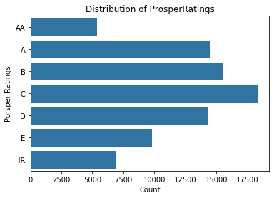

```python
# set the order of the levels in ProsperRatings
prosprtngs = ['AA', 'A', 'B', 'C', 'D', 'E', 'HR']
rtngs = pd.api.types.CategoricalDtype(ordered = True,
                                      categories = prosprtngs)
loan['ProsperRating (Alpha)'] = loan['ProsperRating (Alpha)'].astype(rtngs)

# the ProsperRatings distribution
sb.countplot(data = loan, y = 'ProsperRating (Alpha)', color = color_base)

plt.xlabel('Count')
plt.ylabel('Porsper Ratings')
plt.title('Distribution of ProsperRatings')
```

## Data Wrangling before further exploration

Because the ProsperRating records did not exist prior to July 2009, it shows as missing data in the earlier records. Prior to 2009, the CreditGrade was used as the evaluation system by Prosper. Since we have more ProsperRating over CrediGrade records, the rows with the CrediGrade records will be excluded from this analysis. The additional rows with the conditions below will also be exclude.

- The borrower's income information is missing
- The borrower rate is above 0.35
- Missing employment status information
- Credit socre lower than 400

```python
loan = loan.dropna(subset=['IncomeRange', 'EmploymentStatus',
                             'CreditScoreRangeLower', 'CreditScoreRangeUpper',
                             'ProsperRating (Alpha)'])
loan.shape
```

```
(84853, 81)
```

```python
# remove the rows with 'CreditGrade' records
loan = loan[loan['CreditGrade'].isnull()]

loan = loan[loan['CreditScoreRangeUpper'] > 400]
loan = loan[loan['BorrowerRate'] < 0.35]

loan.shape
```

```
(84046, 81)
```

```python
# set the order of the ProsperRatings
prosprtngs = ['AA', 'A', 'B', 'C', 'D', 'E', 'HR']
rtngs = pd.api.types.CategoricalDtype(ordered = True,
                                      categories = prosprtngs)
loan['ProsperRating (Alpha)'] = loan['ProsperRating (Alpha)'].astype(rtngs)
```

```python
# set the order of the IncomeRanges
incomnrngs = ['$1-24,999', '$25,000-49,999', '$50,000-74,999',
             '$75,000-99,999', '$100,000+']
incomns = pd.api.types.CategoricalDtype(ordered = True,
                                        categories = incomnrngs)
loan['IncomeRange'] = loan['IncomeRange'].astype(incomns)
```

## The borrower rate distribution by Prosper Ratings

> - The Borrower Rate histogram is highly correlated with the Prosper Rating. The decreasing prosper rate (which indicates the increasing risks) is correlated with an increasing borrower rate.

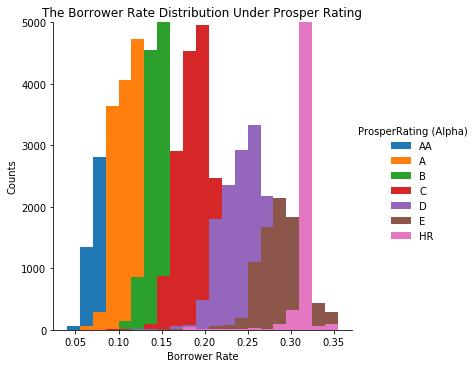

```python
# plotting histogram
binsize = 0.015
bins = np.arange(0.04, loan['BorrowerRate'].max()+binsize, binsize);
#group_order = ['AA', 'A', 'B', 'C', 'D', 'E', 'HR']

# plot the histogram of the BorrowerRate
g = sb.FacetGrid(data = loan, hue = 'ProsperRating (Alpha)',
                 height = 5)
g.map(plt.hist, 'BorrowerRate', bins = bins, histtype = 'bar', stacked = True)
g.add_legend()
g.set(ylim = (0, 5000))
plt.xlabel('Borrower Rate')
plt.ylabel('Counts')
plt.title('The Borrower Rate Distribution Under Prosper Rating');
```

## The borrower rate distribution by Income Ranges

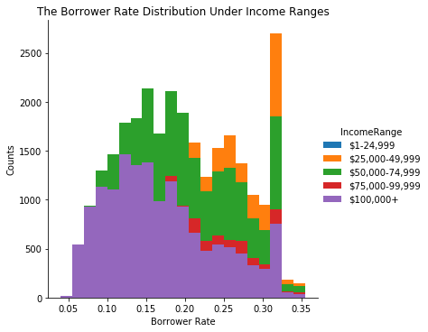

```python
# plotting histogram
binsize = 0.015
bins = np.arange(0.04, loan['BorrowerRate'].max()+binsize, binsize);
#group_order = ['AA', 'A', 'B', 'C', 'D', 'E', 'HR']

# plot the histogram of the BorrowerRate
g = sb.FacetGrid(data = loan, hue = 'IncomeRange',
                 height = 5)
g.map(plt.hist, 'BorrowerRate', bins = bins, histtype = 'bar', stacked = True)
g.add_legend()
#g.set(ylim = (0, 5000))
plt.xlabel('Borrower Rate')
plt.ylabel('Counts')
plt.title('The Borrower Rate Distribution Under Income Ranges')
```

## The Borrower Rate Distribution by Employment Status

> - The plot also showed most the borrowers are employed.

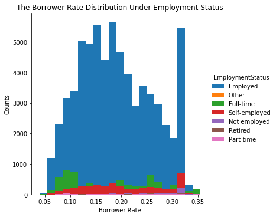

```python
# plotting histogram
binsize = 0.015
bins = np.arange(0.04, loan['BorrowerRate'].max()+binsize, binsize);
#group_order = ['AA', 'A', 'B', 'C', 'D', 'E', 'HR']

# plot the histogram of the BorrowerRate
g = sb.FacetGrid(data = loan, hue = 'EmploymentStatus',
                 height = 5)
g.map(plt.hist, 'BorrowerRate', bins = bins, histtype = 'bar')
g.add_legend()
#g.set(ylim = (0, 5000))
plt.xlabel('Borrower Rate')
plt.ylabel('Counts')
plt.title('The Borrower Rate Distribution Under Employment Status')
```

## Will owning a house help to lower the borrower rate?

> - Being a house owner does help to decrease the borrowing rate in the given dataset.

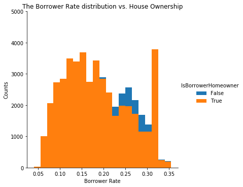

```python
# plotting histogram
binsize = 0.015
bins = np.arange(0.04, loan['BorrowerRate'].max()+binsize, binsize);
#group_order = ['AA', 'A', 'B', 'C', 'D', 'E', 'HR']

# plot the histogram of the BorrowerRate
g = sb.FacetGrid(data = loan, hue = 'IsBorrowerHomeowner',
                 height = 5)
g.map(plt.hist, 'BorrowerRate', bins = bins, histtype = 'bar')
g.add_legend()
g.set(ylim = (0, 5000))
plt.xlabel('Borrower Rate')
plt.ylabel('Counts')
plt.title('The Borrower Rate distribution vs. House Ownership')
```

## Summary:

> - Prosper rating is highly correlated with the borrower rate. An improving prosper rating(from HR to AA means the risk is from high to low) indicates a decreasing borrower rate.
> - Higher income makes the borrower rate distribution peak shift towards the left.
> - Most borrowers are employed.
> - Being a house owner does help to lower the borrower rate.

*Now we have a general idea about the borrower rate. Let's take a look at how Prosper Rating evaluate the borrowers.*

## House owner get better Prosper rating?

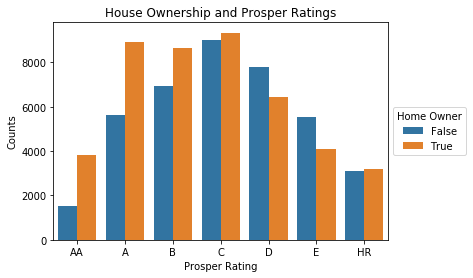

```python
prosprtng_order = ['AA', 'A', 'B', 'C', 'D', 'E', 'HR']
#housownr_order = [True, False]

sb.countplot(data = loan, x = 'ProsperRating (Alpha)',
             hue = 'IsBorrowerHomeowner')

g.add_legend()
plt.legend(['False', 'True'], title = 'Home Owner',
           loc = 6, bbox_to_anchor = (1.0, 0.5))
plt.xlabel('Prosper Rating')
plt.ylabel('Counts')
plt.title('House Ownership and Prosper Ratings')
```

## The odd 4k peak was caused by borrowers with bad Prosper ratings

> - The plot shows the borrower has higher prosper rating scales D, E, and HR (high risk) obtain less amount of loan money. **The average amount of the loan money for E and HR borrowers is around 4k**.
> - Since the borrower with high prosper rating scale indicate a high risk, it is reasonable that these borrowers (D, E, HR) will have more difficulties to borrow larger loan amounts on the Prosper platform

*The highly **aggregated 4k loan amount for the E and HR borrowers** explained the 4k peak in the first loan amount distribution histogram chart ealier.*

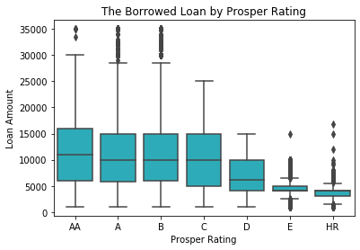

```python
base_color = sb.color_palette()[9]

# the first, ProsperRating vs. LoanOriginalAmount

ax0 = sb.boxplot(data = loan, x = 'ProsperRating (Alpha)',
                 y = 'LoanOriginalAmount', color = base_color)
plt.xlabel('Prosper Rating')
plt.ylabel('Loan Amount')
plt.title('The Borrowed Loan by Prosper Rating')
```

## Better prosper rating lower borrower rate

> - The borrower rate shows a linear relationship to prosper rating. The deteorating prosper rating leads to rising borrower rate.

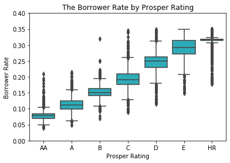

```python
ax4 = sb.boxplot(data = loan, x = 'ProsperRating (Alpha)',
                 y = 'BorrowerRate', color = base_color)
plt.ylim(0, 0.4)
plt.xlabel('Prosper Rating')
plt.ylabel('Borrower Rate')
plt.title('The Borrower Rate by Prosper Rating')
```

## Prosper Rating is consistent with Credit Score

> - The plot shows the ProsperRating system is generally consistent with the CreditScoreRangeUpper system becuase higher PropsperRating scale (low risk) is associate with higher CreditScoreRangeUpper Score.

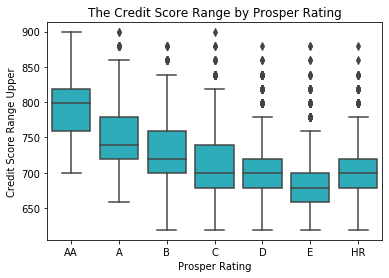

```python
ax1 = sb.boxplot(data = loan, x = 'ProsperRating (Alpha)',
                 y = 'CreditScoreRangeUpper', color = base_color)
plt.xlabel('Prosper Rating')
plt.ylabel('Credit Score Range Upper')
plt.title('The Credit Score Range by Prosper Rating')
```

## Improved Prosper rating indicates a lower debt pressure

> - The plot shows the debt to income ratio raises as the prosper rating decreases.

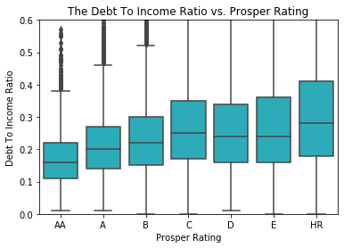

```python
ax2 = sb.boxplot(data = loan, x = 'ProsperRating (Alpha)',
                 y = 'DebtToIncomeRatio', color = base_color)
plt.ylim(0, 0.6)
plt.xlabel('Prosper Rating')
plt.ylabel('Debt To Income Ratio')
plt.title('The Debt To Income Ratio vs. Prosper Rating')
```

## Higher income indicates a lower debt pressure as well

> - The plot shows as the income range increases, the debt to income ratio decreases.

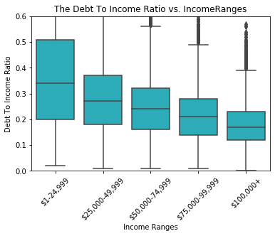

```python
ax3 = sb.boxplot(data = loan, x = 'IncomeRange',
                 y = 'DebtToIncomeRatio', color = base_color)
plt.ylim(0, 0.6)
plt.xlabel('Income Ranges')
plt.ylabel('Debt To Income Ratio')
plt.title('The Debt To Income Ratio vs. IncomeRanges')
plt.xticks(rotation = 45)
```

## To further confirm the above findings, let's combine both Prosper rating and income range measurements

> - The plot shows within each income range, the improving prosper rating yields a droping of the debt to income ratio.
> - Besides, the raising income range also showed a droping trend of the debt to income ratio.
> - There are more outliers in the lower income ranges with extremely high debt to income ratio.

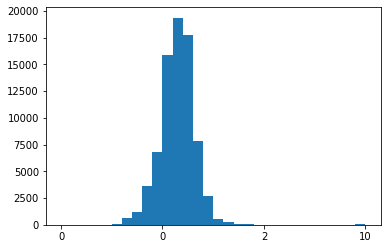

```python
# apply cuberoot transformation
def qrt_trans(x, inverse = False):
    """transformation helper function"""
    if not inverse:
        return x ** (1/4)
    else:
        return x ** 4

bin_edges = np.arange(0, qrt_trans(loan['DebtToIncomeRatio'].max())+0.06, 0.06);
plt.hist(loan['DebtToIncomeRatio'].apply(qrt_trans), bins = bin_edges);
tick_locs = np.arange(0, qrt_trans(loan['DebtToIncomeRatio'].max())+0.6, 0.6);
plt.xticks(tick_locs, qrt_trans(tick_locs, inverse = True).astype(int));
```

```python
loan['DebtToIncomeRatio_qrt'] = loan['DebtToIncomeRatio'].apply(qrt_trans)
print(qrt_trans(0.1))
print(qrt_trans(10))
```

```
0.5623413251903491
1.7782794100389228
```

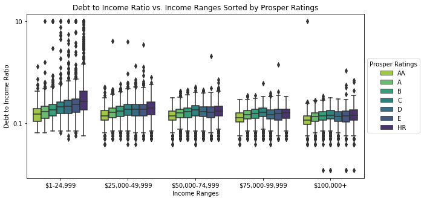

```python
# seaborn cluster boxplot will be applied
plt.figure(figsize = [10, 5])
sb.boxplot(data = loan, x = 'IncomeRange', y = 'DebtToIncomeRatio_qrt',
           hue = 'ProsperRating (Alpha)', palette = 'viridis_r')
#sb.regplot(data = loan, x = 'IncomeRange', y = 'DebtToIncomeRatio_qrt', scatter = False)

plt.legend(loc = 6, bbox_to_anchor = (1.0, 0.5), title = 'Prosper Ratings')

# set the y- axis ticks
plt.yticks([0.5623413251903491, 1.7782794100389228], ['0.1', '10']);

plt.xlabel('Income Ranges')
plt.ylabel('Debt to Income Ratio')
plt.title('Debt to Income Ratio vs. Income Ranges Sorted by Prosper Ratings')
```

## The prosper rating, borrower rate, and estimated yield

> - The plot shows at the same borrower rate (like 0.2, 0.25), the estimated yield is below zero for HR (high risk borrower) but positive for AA, A and B (low risk borrowers).
> - The plot also reflects although the higher risk scale on the prosper ratings brings higher borrower rate, but due to the increased risk, the estimated yield may get compromised as well.

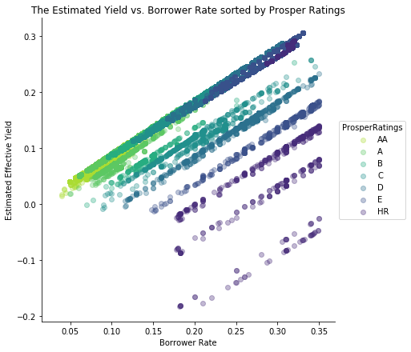

```python
# right one, scatter plot of the two numeric variables (borrowerRate EstimatedEffYield)
# plus the categorical variable ProsperRatings

g = sb.FacetGrid(data = loan, hue = 'ProsperRating (Alpha)', height = 6,
                 palette = 'viridis_r')
g.map(plt.scatter, 'BorrowerRate', 'EstimatedEffectiveYield', alpha = 1/3)
plt.legend(['AA', 'A', 'B', 'C', 'D', 'E', 'HR'], title = 'ProsperRatings',
           loc = 6, bbox_to_anchor = (1.0, 0.5))
plt.xlabel('Borrower Rate')
plt.ylabel('Estimated Effective Yield')
plt.title('The Estimated Yield vs. Borrower Rate sorted by Prosper Ratings');
```

## What about loss?

> - The plot shows the improving prosper rating lower the borrow rate, it reduces the estimated loss as well.

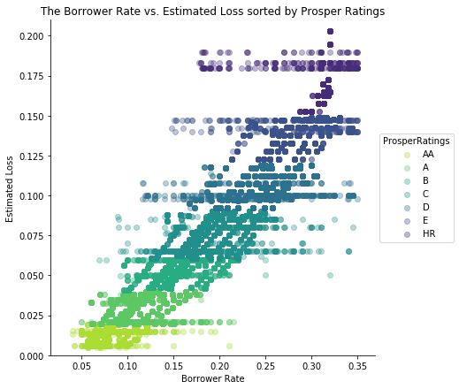

```python
# right one, scatter plot of the two numeric variables (borrowerRate EstimatedEffYield)
# plus the categorical variable ProsperRatings

g = sb.FacetGrid(data = loan, hue = 'ProsperRating (Alpha)', height = 6,
                 palette = 'viridis_r')
g.map(plt.scatter, 'BorrowerRate', 'EstimatedLoss', alpha = 1/3)
plt.legend(['AA', 'A', 'B', 'C', 'D', 'E', 'HR'], title = 'ProsperRatings',
           loc = 6, bbox_to_anchor = (1.0, 0.5))
plt.ylim(0, 0.21)
plt.xlabel('Borrower Rate')
plt.ylabel('Estimated Loss')
plt.title('The Borrower Rate vs. Estimated Loss sorted by Prosper Ratings');
```

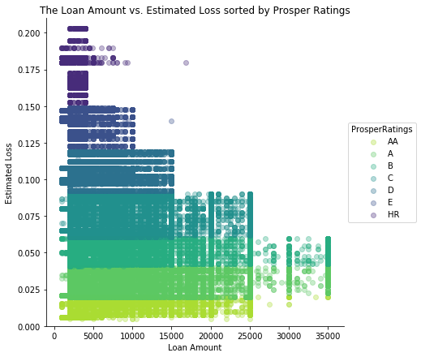

```python
# right one, scatter plot of the two numeric variables (borrowerRate EstimatedEffYield)
# plus the categorical variable ProsperRatings

g = sb.FacetGrid(data = loan, hue = 'ProsperRating (Alpha)', height = 6,
                 palette = 'viridis_r')
g.map(plt.scatter, 'LoanOriginalAmount', 'EstimatedLoss', alpha = 1/3)
plt.legend(['AA', 'A', 'B', 'C', 'D', 'E', 'HR'], title = 'ProsperRatings',
           loc = 6, bbox_to_anchor = (1.0, 0.5))
plt.ylim(0, 0.21)
plt.xlabel('Loan Amount')
plt.ylabel('Estimated Loss')
plt.title('The Loan Amount vs. Estimated Loss sorted by Prosper Ratings');
```

## Now we know that the Prosper rating can reflect borrower's debt pressure and predict borrower's risk. But the loan amount is what the borrower cares most and we need to know whether the investors can take advantages of the Prosper system to reduce their risk and maximize their profits.

## *Lets first take a look at the two heat maps of loan amount vs. borrower rate and loan amount vs. investor distribution*

## The heat maps of borrower rate vs. loan amount; loan amount vs. investors

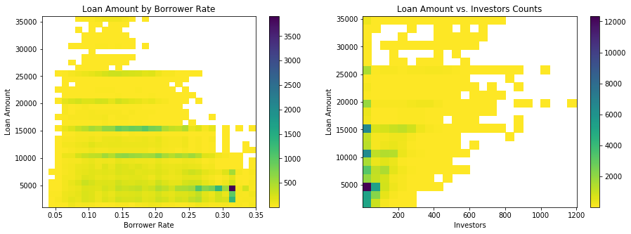

```python
plt.figure(figsize = [15, 5])
# plot a hist map of BorrowerRate vs. LoanOriginalAmount
plt.subplot(1, 2, 1)
bins_x = np.arange(0.03, loan['BorrowerRate'].max()+0.01, 0.01)
bins_y = np.arange(999, loan['LoanOriginalAmount'].max()+1000, 1000)

plt.hist2d(data = loan, x = 'BorrowerRate', y = 'LoanOriginalAmount',
           cmap = 'viridis_r', cmin = 0.5, bins = [bins_x, bins_y])
plt.colorbar()
plt.xlabel('Borrower Rate')
plt.ylabel('Loan Amount')
plt.title('Loan Amount by Borrower Rate')

# the right plot
plt.subplot(1, 2, 2)
# plot a hist map of Investors vs. StatedMonthlyIncome
bins_x = np.arange(0.99, loan['Investors'].max()+50, 50)
bins_y= np.arange(999, loan['LoanOriginalAmount'].max()+1500, 1500)

plt.hist2d(data = loan, x = 'Investors', y = 'LoanOriginalAmount',
           cmap = 'viridis_r', cmin = 0.5, bins = [bins_x, bins_y])

plt.colorbar()
plt.ylabel('Loan Amount')
plt.xlabel('Investors')
#plt.title(' by Borrower Rate')
plt.title('Loan Amount vs. Investors Counts')
```

```python
(loan['Investors'].describe()) ** 1/2
```

```
count    42023.000000
mean        34.238381
std         47.785784
min          0.500000
25%          0.500000
50%         15.500000
75%         49.000000
max        594.500000
Name: Investors, dtype: float64
```

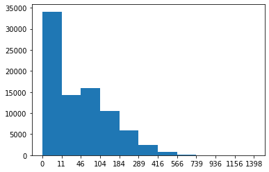

```python
# apply cuberoot transformation
def sqrt_trans(x, inverse = False):
    """transformation helper function"""
    if not inverse:
        return x ** (1/2)
    else:
        return x ** 2

bin_edges = np.arange(0, sqrt_trans(loan['Investors'].max())+3.4, 3.4);
plt.hist(loan['Investors'].apply(sqrt_trans), bins = bin_edges);
tick_locs = np.arange(0, sqrt_trans(loan['Investors'].max())+3.4, 3.4);
plt.xticks(tick_locs, sqrt_trans(tick_locs, inverse = True).astype(int));
```

```python
loan['Investors_sqrt'] = loan['Investors'].apply(sqrt_trans)
loan['Investors_sqrt'].describe()
```

```
count    84046.000000
mean         6.326130
std          5.334527
min          1.000000
25%          1.000000
50%          5.567764
75%          9.899495
max         34.481879
Name: Investors_sqrt, dtype: float64
```

```python
print(sqrt_trans(1200))
print(sqrt_trans(500))
```

```
34.64101615137755
22.360679774997898
```

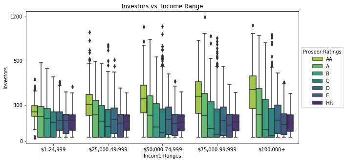

```python
# seaborn cluster boxplot will be applied
plt.figure(figsize = [10, 5])
sb.boxplot(data = loan, x = 'IncomeRange', y = 'Investors_sqrt',
           hue = 'ProsperRating (Alpha)', palette = 'viridis_r')
#sb.regplot(data = loan, x = 'IncomeRange', y = 'DebtToIncomeRatio_qrt', scatter = False)

plt.legend(loc = 6, bbox_to_anchor = (1.0, 0.5), title = 'Prosper Ratings')

# set the y- axis ticks
#plt.yticks([0.5623413251903491, 1.7782794100389228], ['0.1', '10']);
plt.yticks([0, 10, 22.360679774997898, 34.64101615137755], [0, 100, 500, 1200])
plt.xlabel('Income Ranges')
plt.ylabel('Investors')
plt.title('Investors vs. Income Range')
```

## The investor distribution by borrower rate

> - The plot shows a borrower with better prosper ratings has more investors and lower borrower rate.
> - The plot also indicates the investors in general prefer to invest the borrowers with lower risk, even it means sacrifice with lower borrower rate.

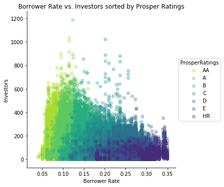

```python
# two categorical variables plus one numeric variables. Use seaborn FacetScatter plot
g = sb.FacetGrid(data = loan, hue = 'ProsperRating (Alpha)', height = 5,
                 palette = 'viridis_r')
g.map(plt.scatter, 'BorrowerRate', 'Investors', alpha = 1/3)
plt.legend(['AA', 'A', 'B', 'C', 'D', 'E', 'HR'], title = 'ProsperRatings',
           loc = 6, bbox_to_anchor = (1.0, 0.5))
plt.xlabel('Borrower Rate')
plt.ylabel('Investors')
plt.title('Borrower Rate vs. Investors sorted by Prosper Ratings');
```

## The investor's distribution by the loan amount

> - The borrowers with the best Prosper rating AA were the most prefered by the investors.
> - The borrowers with the best Prosper rating AA were also easier to borrow large amount of money from the Prosper platform.
> - The Prosper rating lower than B borrowers can hardly borrow more than USD30k loans.
> - The above results indicate the Prosper rating system significantly influenced the investors' preference over the borrowers and makes the borrowers with lower Prosper rating much harder to borrow large amount of loan.

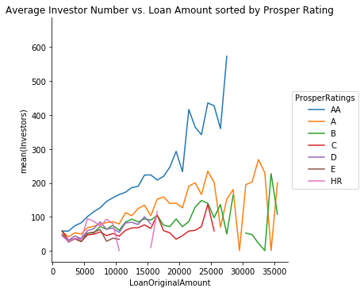

```python
def mean_poly(x, y, bins = bin_edges, **kwargs):
    """Custom adapted line plot code."""
    # set bin edges if non or int specified
    if type(bins) == int:
        bins = np.linspace(x.min(), x.max(), bins+1)
    bin_centers = (bin_edges[1:] + bin_edges[:-1]) / 2

    # compute counts
    data_bins = pd.cut(x, bins, right = False,
                       include_lowest = True)
    means = y.groupby(data_bins).mean()

    # create plot
    plt.errorbar(x = bin_centers, y = means, **kwargs)

bin_edges = np.arange(999, loan['LoanOriginalAmount'].max()+1000, 1000)
g = sb.FacetGrid(data = loan, hue = 'ProsperRating (Alpha)', height = 5)
g.map(mean_poly, 'LoanOriginalAmount', 'Investors', bins = bin_edges)
g.set_ylabels('mean(Investors)')
plt.legend(['AA', 'A', 'B', 'C', 'D', 'E', 'HR'], title = 'ProsperRatings',
           loc = 6, bbox_to_anchor = (1.0, 0.5))
plt.title('Average Investor Number vs. Loan Amount sorted by Prosper Rating')
```

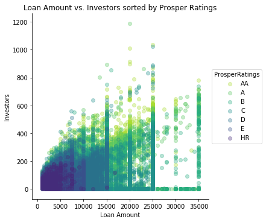

```python
g = sb.FacetGrid(data = loan, hue = 'ProsperRating (Alpha)', height = 5,
                 palette = 'viridis_r')
g.map(plt.scatter, 'LoanOriginalAmount', 'Investors', alpha = 1/3)
plt.legend(['AA', 'A', 'B', 'C', 'D', 'E', 'HR'], title = 'ProsperRatings',
           loc = 6, bbox_to_anchor = (1.0, 0.5))
plt.xlabel('Loan Amount')
plt.ylabel('Investors')
plt.title('Loan Amount vs. Investors sorted by Prosper Ratings');
```

## Borrower's income, loan payment, income ranges, and prosper rating

> - The borrower with higher income can afford higher loan payment
> - The borrower with better prosper rating seems can afford higher loan payment

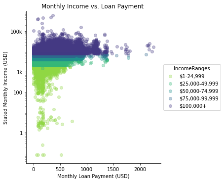

```python
g = sb.FacetGrid(data = loan, hue = 'IncomeRange', height = 5,
                 palette = 'viridis_r')
g.map(plt.scatter, 'MonthlyLoanPayment', 'StatedMonthlyIncome', alpha = 1/3)
plt.legend(['$1-24,999', '$25,000-49,999', '$50,000-74,999', '$75,000-99,999', '$100,000+'], title = 'IncomeRanges',
           loc = 6, bbox_to_anchor = (1.0, 0.5))
plt.yscale('log')
plt.ylim(0, 1000000)
plt.yticks([1, 100, 1000, 100000], ['1', '100', '1k', '100k']);
plt.xlabel('Monthly Loan Payment (USD)')
plt.ylabel('Stated Monthly Income (USD)')
plt.title('Monthly Income vs. Loan Payment ')
```

[output not shown]

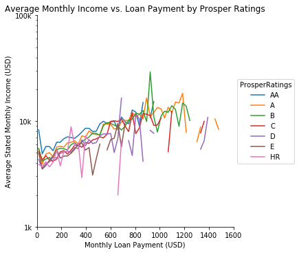

```python
def mean_poly(x, y, bins = bin_edges, **kwargs):
    """Custom adapted line plot code."""
    # set bin edges if non or int specified
    if type(bins) == int:
        bins = np.linspace(x.min(), x.max(), bins+1)
    bin_centers = (bin_edges[1:] + bin_edges[:-1]) / 2

    # compute counts
    data_bins = pd.cut(x, bins, right = False,
                       include_lowest = True)
    means = y.groupby(data_bins).mean()

    # create plot
    plt.errorbar(x = bin_centers, y = means, **kwargs)

bin_edges = np.arange(0, loan['MonthlyLoanPayment'].max()+29.3, 29.3)
g = sb.FacetGrid(data = loan, hue = 'ProsperRating (Alpha)', height = 5)
g.map(mean_poly, 'MonthlyLoanPayment', 'StatedMonthlyIncome', bins = bin_edges)
g.set_ylabels('mean(Investors)')
plt.legend(['AA', 'A', 'B', 'C', 'D', 'E', 'HR'], title = 'ProsperRatings',
           loc = 6, bbox_to_anchor = (1.0, 0.5))
plt.title('Average Investor Number vs. Loan Amount sorted by Prosper Rating')
plt.yscale('log')
plt.yticks([1000, 10000, 100000], ['1k', '10k', '100k']);
plt.xlabel('Monthly Loan Payment (USD)')
plt.ylabel('Average Stated Monthly Income (USD)')
plt.title('Average Monthly Income vs. Loan Payment by Prosper Ratings');
plt.ylim(1000, 100000)
plt.xlim(0, 1600)
```

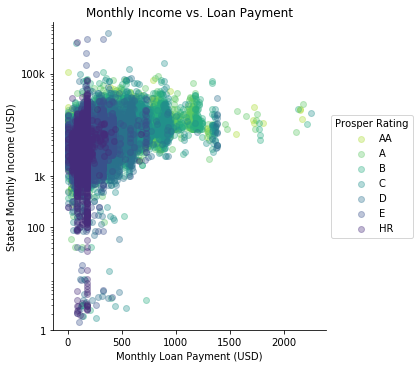

```python
g = sb.FacetGrid(data = loan, hue = 'ProsperRating (Alpha)', height = 5,
                 palette = 'viridis_r')
g.map(plt.scatter, 'MonthlyLoanPayment', 'StatedMonthlyIncome', alpha = 1/3)
plt.legend(title = 'Prosper Rating',
           loc = 6, bbox_to_anchor = (1.0, 0.5))
plt.yscale('log')
plt.ylim(0, 1000000)
plt.yticks([1, 100, 1000, 100000], ['1', '100', '1k', '100k']);
plt.xlabel('Monthly Loan Payment (USD)')
plt.ylabel('Stated Monthly Income (USD)')
plt.title('Monthly Income vs. Loan Payment');
```

```python
loan['MonthlyLoanPayment'].describe()
```

```
count    84046.000000
mean       293.444275
std        186.691029
min          0.000000
25%        158.870000
50%        253.930000
75%        389.880000
max       2251.510000
Name: MonthlyLoanPayment, dtype: float64
```

## Final Summary

> - The Prosper rating system can reflect the borrowers' debt pressure and designate different borrower rate according to the borrower base on his/her financial records.
> - The Prosper rating system shows the same trend of the borrower's debt pressure as the income range does.
> - Most investors prefer the low risk ,low borrower rate loan to invest.
> - Borrowers with high monthly income enabled them to borrow higher loan amounts.

> Once you're ready to finish your presentation, check your output by using nbconvert to export the notebook and set up a server for the slides. From the terminal or command line, use the following expression:

> > `jupyter nbconvert <file_name>.ipynb --to slides --post serve --template output_toggle`

> This should open a tab in your web browser where you can scroll through your presentation. Sub-slides can be accessed by pressing 'down' when viewing its parent slide. Make sure you remove all of the quote-formatted guide notes like this one before you finish your presentation!